# Final project

Borbala German

2018 január 21

# Associations between the executive functions and the Event related potentials responses.

## Abstract

### Description of the dataset (source, format, variables)

The dataset is coming from an ongoing research project of my PhD research.

For the analysis nine variables were used: two electrophysiological variables and seven neuropsychological variables.

The EEG were recorded during an odd-ball paradigmn with the help of pseudowords and the examined time windows were selected by a TANOVA. The interest of my hypothesis was to examine the possible relationship between the executive functions measured by neuropsychological tests and the MMN responses for the native word stress. In the appropriate time window (378 -444 ms) hu_str1_diff_2nd variable as MMN effect was calculated as the mean amplitude of the ERP response for HU S1 (stress on the first sylabble) as deviant stimuli minus the mean amplitude for HU S1 as standard stimuli. The hu_str2_diff_2nd variable as MMN effect was calculated as the mean amplitude of the ERP responses for HU S2 (stress on the second sylabble) as deviant stimuli minus the mean amplitude for HU S2 as standard stimuli. These two variables show the magnitude of the evoked potential (MMN) for the deviant as compared to thestimuli related to the standard stimuli.

To examine the main components of executive functions – inhibition, switching, and working memory (Miyake et al., 2000) –, we used auditory Go/No-Go task, Counting span task, and Verbal Fluency task. We used the discriminability index (Pr) (Hershey et al., 2010) from Go/No-Go task what was calculated as the ratio of hits (correct responses for Go trials) and false alarms (responses for the No-Go trials) to measure task performance.From Counting span task we calculated the Working memory capacity the mean of performance (Cs_avg) .From the verbal fluency task we used qualitative and quantitative variables, as qualitative: the number of clusters (including phonemic and semantic clusters, as well; avg_groupnumb), the size of the clusters (number of words in a cluster minus one according to the criterion of Troyer et al. (1997);avg_groupsize), sharp switching (avg_sharpswitch), and cluster switching averaged (avg_clustswitch) across the different subtasks were calculated for each participan and all the number of all generated words (fluency)

All variables are numeric.

It is an exploratory data analysis, so I don’t investigated a specific hypothesis. I conducted a correlation analysis and the adequate corrections (Bonferroni correction and Benjamini-Hochberg method). After this I ran a linear regression analysis to discover the possible models which could explain the MMN variables. After these type of analysis I tried to find a solution which is more robust, so I ran a permutation statistics on the correlation coefficients to find the reliable results.

### Exploratory data analysis

For exploratory data analysis I called in the dataset and ran a descriptive analysis. With the help of the table I checked the mean, sd, min and max values to emanie the misswritting or other mistakes and see the ranges of the variables.

```r
install.packages("psych")
library(psych)
library(Hmisc)

descriptive <- describe(data)
print(descriptive)
```

```
## data
##
##  10  Variables      30  Observations
## ---------------------------------------------------------------------------
## id
##        n  missing distinct     Info     Mean      Gmd      .05      .10
##       30        0       30        1     15.5    10.33     2.45     3.90
##      .25      .50      .75      .90      .95
##     8.25    15.50    22.75    27.10    28.55
##
## lowest :  1  2  3  4  5, highest: 26 27 28 29 30
## ---------------------------------------------------------------------------
## hu_str1_diff_2nd
##        n  missing distinct     Info     Mean      Gmd      .05      .10
##       30        0       28        1    -0.55    1.384  -2.2695  -1.7480
##      .25      .50      .75      .90      .95
##  -1.2600  -0.4700   0.1025   1.0160   1.5290
##
## lowest : -4.16 -2.49 -2.00 -1.72 -1.57, highest:  0.71  0.97  1.43  1.61  1.67
## ---------------------------------------------------------------------------
## hu_str2_diff_2nd
##        n  missing distinct     Info     Mean      Gmd      .05      .10
##       30        0       30        1   -1.424    1.166  -2.8075  -2.6450
##      .25      .50      .75      .90      .95
##  -2.0425  -1.6050  -0.9850   0.1880   0.7155
##
## lowest : -3.16 -2.83 -2.78 -2.63 -2.50, highest: -0.68  0.13  0.71  0.72  1.07
## ---------------------------------------------------------------------------
## Cs_avg
##        n  missing distinct     Info     Mean      Gmd
##       30        0        9    0.978    3.776   0.7763
##
## Value       2.67  3.00  3.33  3.67  4.00  4.33  4.67  5.00  5.28
## Frequency      2     4     6     4     5     5     2     1     1
## Proportion 0.067 0.133 0.200 0.133 0.167 0.167 0.067 0.033 0.033
## ---------------------------------------------------------------------------
## Pr
##        n  missing distinct     Info     Mean      Gmd      .05      .10
##       30        0       24    0.999   0.7267    0.233   0.4090   0.4200
##      .25      .50      .75      .90      .95
```

[output cut: 41 more lines]

```
## ---------------------------------------------------------------------------
## avg_groupnumb
##        n  missing distinct     Info     Mean      Gmd      .05      .10
##       30        0       17    0.994    1.022   0.3575   0.5825   0.7090
##      .25      .50      .75      .90      .95
##   0.8300   1.0000   1.2800   1.5000   1.5000
##
## Value       0.33  0.56  0.61  0.72  0.78  0.83  0.89  0.94  1.00  1.06
## Frequency      1     1     1     1     3     4     2     1     3     2
## Proportion 0.033 0.033 0.033 0.033 0.100 0.133 0.067 0.033 0.100 0.067
##
## Value       1.11  1.17  1.28  1.33  1.39  1.50  1.61
## Frequency      1     1     3     1     1     3     1
## Proportion 0.033 0.033 0.100 0.033 0.033 0.100 0.033
## ---------------------------------------------------------------------------
```

I plotted histograms and scatter plots to examine the distribution of the variables, and boxplots to see the possible outliers. I made two separate plot table, on the first exploratory plot I illustrated the MMN variables.

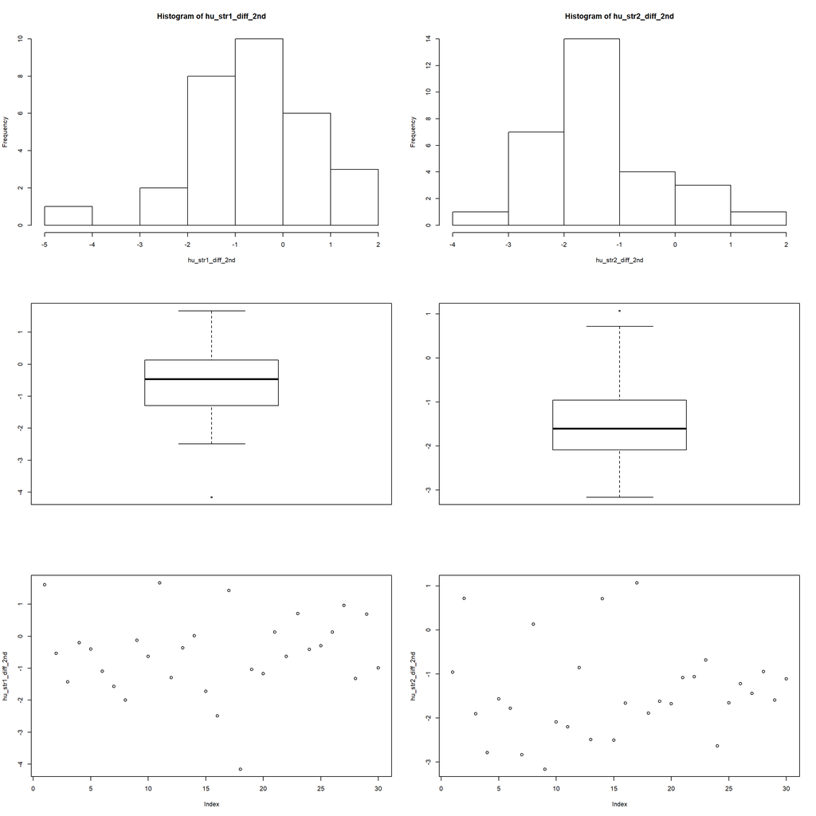

```r
attach(data)

par(mfrow= c(3,2))
hist(hu_str1_diff_2nd)
hist(hu_str2_diff_2nd)
boxplot(hu_str1_diff_2nd)
boxplot(hu_str2_diff_2nd)
plot(hu_str1_diff_2nd)
plot(hu_str2_diff_2nd)
```

On the second the exploratory data analysis of the EF variables were demonstrated.

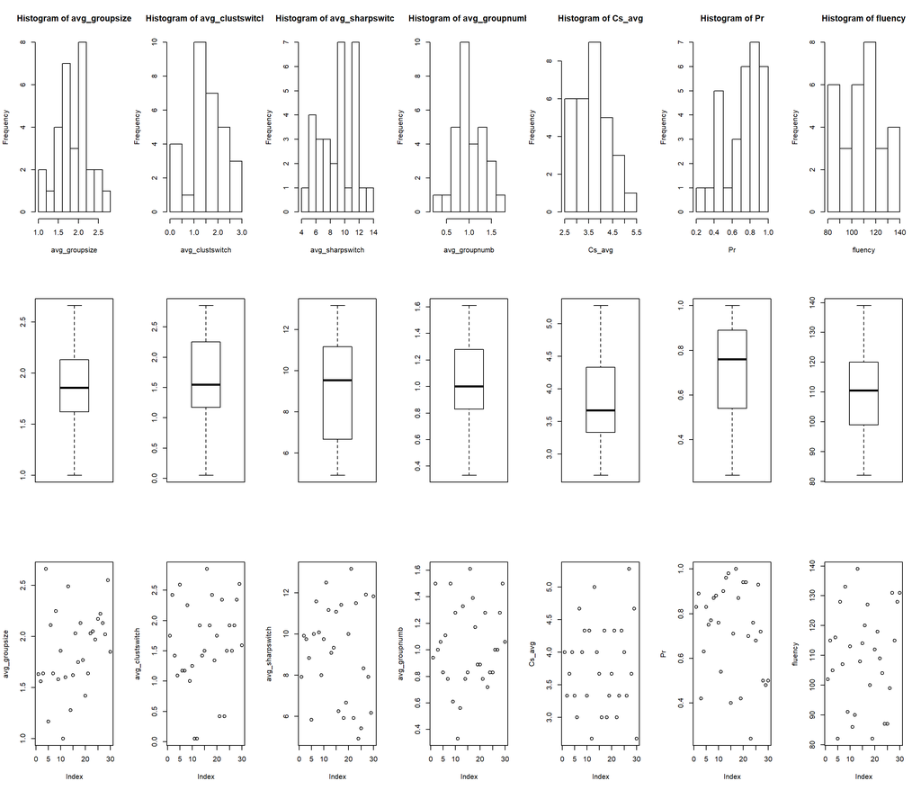

```r
par(mfrow= c(3,7))

hist(avg_groupsize)
hist(avg_clustswitch)
hist(avg_sharpswitch)
hist(avg_groupnumb)
hist(Cs_avg)
hist(Pr)
hist(fluency)
boxplot(avg_groupsize)
boxplot(avg_clustswitch)
boxplot(avg_sharpswitch)
boxplot(avg_groupnumb)
boxplot(Cs_avg)
boxplot(Pr)
boxplot(fluency)
plot(avg_groupsize)
plot(avg_clustswitch)
plot(avg_sharpswitch)
plot(avg_groupnumb)
plot(Cs_avg)
plot(Pr)
plot(fluency)
```

```r
dev.off()
```

```
FALSE null device
FALSE           1
```

To check the normality of the variables I conducted Shapiro-Wilks tests.

```r
#normality check

lshap <- lapply(data, shapiro.test)
lres <- sapply(lshap, `[`, c("statistic","p.value"))
shapiro_results <- as.data.frame(lres)
knitr::kable(lres, digits = 4, caption = "Results of Shapiro-Wilks test.")
```

Results of Shapiro-Wilks test.

|  | id | hu_str1_diff_2nd | hu_str2_diff_2nd | Cs_avg | Pr | fluency | avg_groupsize | avg_clustswitch | avg_sharpswitch | avg_groupnumb |
| --- | --- | --- | --- | --- | --- | --- | --- | --- | --- | --- |
| statistic | 0.9574506 | 0.9634672 | 0.9373177 | 0.9622084 | 0.9280077 | 0.9597635 | 0.9809301 | 0.9579807 | 0.9490461 | 0.9714581 |
| p.value | 0.2662327 | 0.3786561 | 0.07703453 | 0.3523233 | 0.04348136 | 0.3054884 | 0.8497136 | 0.2748124 | 0.1593913 | 0.5797995 |

### Correlation analysis

To discover the possible relationships between the variables I created two scatterplot seperately for the two MMN variables.

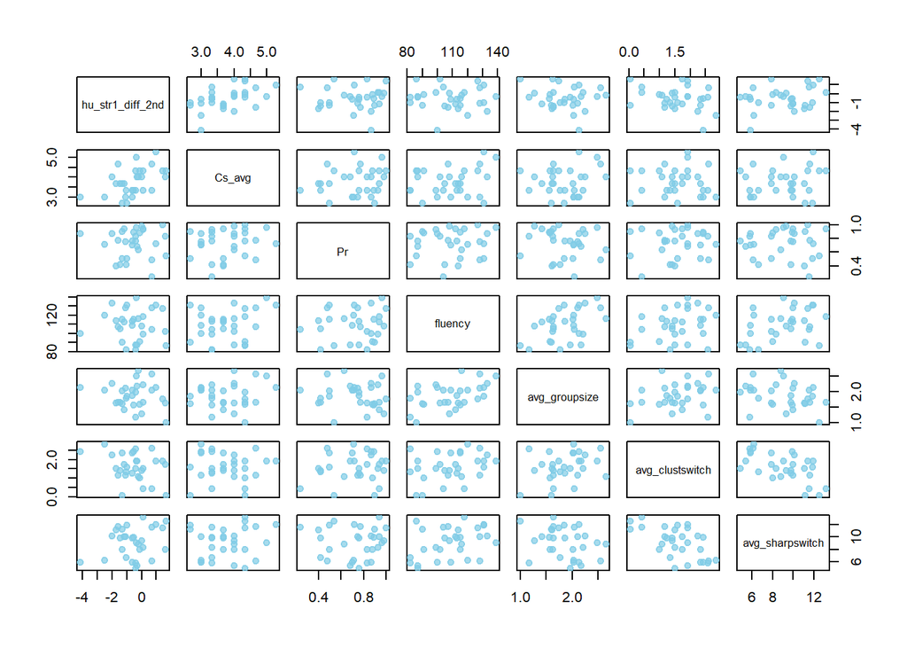

```r
#Creatiing the dataset for hu_str1_diff_2nd
data2 = data[ , c(2,4:9)]
#Make the plot
plot(data2 , pch=20 , cex=1.5 , col=rgb(0.5, 0.8, 0.9, 0.7))
```

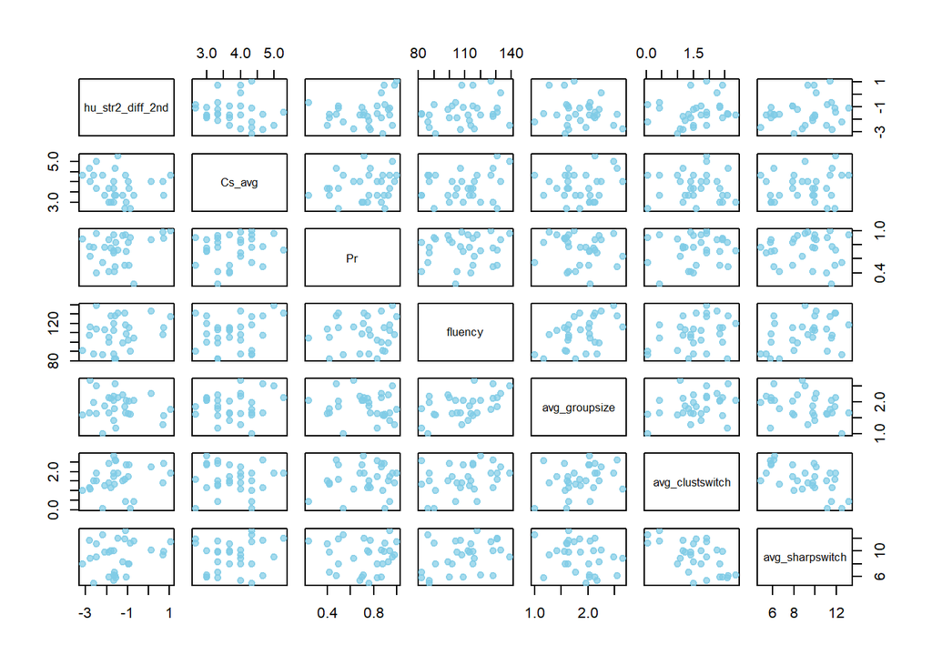

```r
#Creatiing the dataset for hu_str2_diff_2nd
data1=data[ , c(3,4:9)]
#Make the plot
plot(data1 , pch=20 , cex=1.5 , col=rgb(0.5, 0.8, 0.9, 0.7))
```

```r
correl<-cor(data, use = "complete.obs", method = "spearman")

newdata <- data [c(2:10)]
newres <- rcorr(as.matrix(data))

r_matrix <- newres$r
p_matrix <- newres$P
knitr::kable(p_matrix, digits = 3, caption = "A table produced by printr.")
```

A table produced by printr.

|  | id | hu_str1_diff_2nd | hu_str2_diff_2nd | Cs_avg | Pr | fluency | avg_groupsize | avg_clustswitch | avg_sharpswitch | avg_groupnumb |
| --- | --- | --- | --- | --- | --- | --- | --- | --- | --- | --- |
| id | NA | 0.765 | 0.756 | 0.844 | 0.192 | 0.561 | 0.083 | 0.485 | 0.521 | 0.770 |
| hu_str1_diff_2nd | 0.765 | NA | 0.299 | 0.006 | 0.999 | 0.884 | 0.454 | 0.099 | 0.174 | 0.153 |
| hu_str2_diff_2nd | 0.756 | 0.299 | NA | 0.318 | 0.167 | 0.195 | 0.423 | 0.283 | 0.287 | 0.080 |
| Cs_avg | 0.844 | 0.006 | 0.318 | NA | 0.427 | 0.240 | 0.519 | 0.886 | 0.394 | 0.671 |
| Pr | 0.192 | 0.999 | 0.167 | 0.427 | NA | 0.623 | 0.501 | 0.511 | 0.979 | 0.556 |
| fluency | 0.561 | 0.884 | 0.195 | 0.240 | 0.623 | NA | 0.007 | 0.098 | 0.042 | 0.000 |
| avg_groupsize | 0.083 | 0.454 | 0.423 | 0.519 | 0.501 | 0.007 | NA | 0.095 | 0.117 | 0.001 |
| avg_clustswitch | 0.485 | 0.099 | 0.283 | 0.886 | 0.511 | 0.098 | 0.095 | NA | 0.001 | 0.000 |
| avg_sharpswitch | 0.521 | 0.174 | 0.287 | 0.394 | 0.979 | 0.042 | 0.117 | 0.001 | NA | 0.143 |
| avg_groupnumb | 0.770 | 0.153 | 0.080 | 0.671 | 0.556 | 0.000 | 0.001 | 0.000 | 0.143 | NA |

For the easier understanding and visualization I created two correlation matrix: The first plot shows the variables and the correlations between them. Where there is a cube in the cell there is a significant correlation between the two variables. The color of the cube shows the direction of the raltionship, and the shades and the size of the cubes shows the strenght of the relationship.

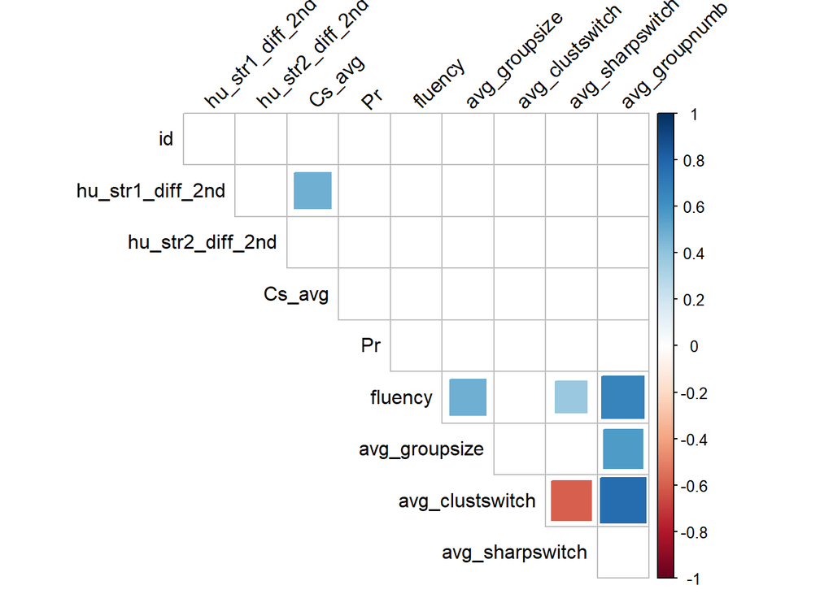

```r
corrplot(newres$r, method = c("square"),
         order="original",
         hclust.method = "average", addrect = 6, rect.col = "black", rect.lwd = 1,
         type="upper", diag = F, tl.col = "black", tl.srt = 45,
         p.mat = newres$P, sig.level = 0.05, insig = "blank")
```

As we can see, only one relation is significant of our interest in this case, between hu_str1_diff_2nd and Cs_avg *p* = .006.

The second plot shows the correlation coefficients at the case of significant results.

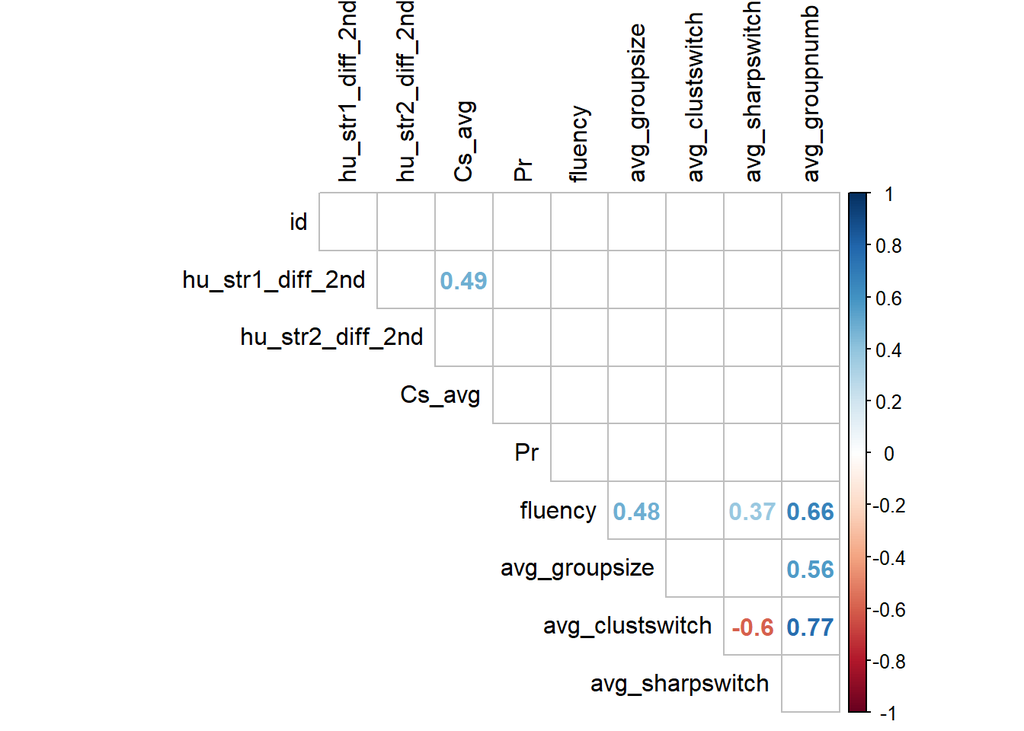

```r
corrplot(newres$r, method = c("number"), type="upper", order="original", diag = F, tl.col = "black",  p.mat = newres$P, sig.level = 0.05, insig = "blank")
```

#### Correction of the multiple comparisons

To control the false discovery rate because of the multiple comparisons I conducted the Bonferroni correction and the Benjamini-Hochberg method. The results are in the further table. As we can see none of the correlation of our interest stayed significant, so with these robust analysis we don’t find any significant relationship between the MMN and the EF variables.

```r
half_matrix <- as.dist(p_matrix)
p_values <- as.vector(half_matrix)
n <- length(p_values)
correction <- as.data.frame(p_values)
p_values = correction[order(correction$p_values),]
correctionData <- as.data.frame(p_values)


correctionData$Bonferroni =
      p.adjust(correctionData$p_values,
                    method = "bonferroni")

correctionData$BH =
    p.adjust(correctionData$p_values,
                   method = "BH")

knitr::kable(correctionData, digits = 3, caption = "Results of the Bonferroni and the Benjamini-Hochberg correction for false discovery rate.")
```

Results of the Bonferroni and the Benjamini-Hochberg correction for false discovery rate.

[output not shown]

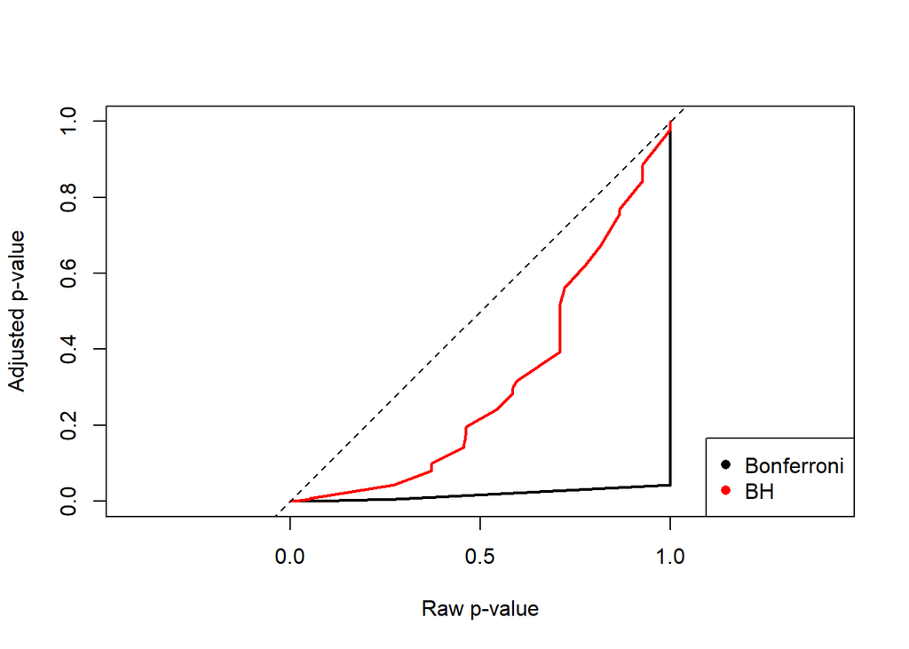

```r
J = correctionData$p_values
K = cbind(correctionData$Bonferroni,
          correctionData$BH)


matplot(K, J,
   xlab="Raw p-value",
   ylab="Adjusted p-value",
   type="l",
   asp=1,
   col=1:6,
   lty=1,
   lwd=2)

legend('bottomright',
   legend = c("Bonferroni", "BH"),
      col = 1:6,
      cex = 1,
      pch = 16)

abline(0, 1,
     col=1,
     lty=2,
     lwd=1)
```

### Linear Regression Model

After the correlation analysis I’d like to explore the models which could describe more succesfully the MMN variables that is why I conducted the linear regression analysis. I built two models with the entered method, so I entered all off the predictor variables and try to predict the MMN variables separately.

Previously in the correlation analysis section I used all of the variables to explore the possible relationships so with that I checked one of the linear regression assumption which is multicollinearity. I found some correlation between the variables which means that the dataset violated the assumption.

I checked the linearity between the predictors and the predicted variables, but I found linearity only at the case of hu_str1_diff_2nd and Cs_avg, that is why I plotted only this relationship.

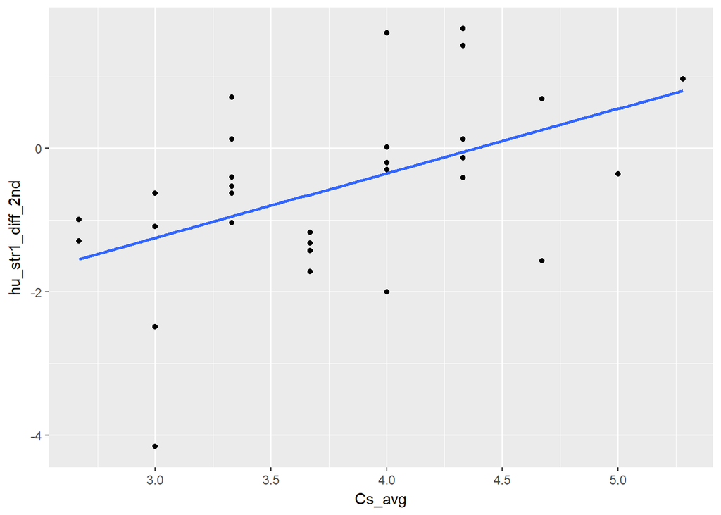

```r
#checking the RESIDUALS

data %>%
  ggplot() +
  aes(y = hu_str1_diff_2nd, x = Cs_avg) +
  geom_point() +
  geom_smooth(method = "lm", se = FALSE)
```

```r
# data %>%
#   ggplot() +
#   aes(y = hu_str1_diff_2nd, x = Pr) +
#   geom_point() +
#   geom_smooth(method = "lm", se = FALSE)
#
# data %>%
#   ggplot() +
#   aes(y = hu_str1_diff_2nd, x = fluency) +
#   geom_point() +
#   geom_smooth(method = "lm", se = FALSE)
#
# data %>%
#   ggplot() +
#   aes(y = hu_str1_diff_2nd, x = avg_groupsize) +
#   geom_point() +
#   geom_smooth(method = "lm", se = FALSE)
#
# data %>%
#   ggplot() +
#   aes(y = hu_str1_diff_2nd, x =avg_clustswitch) +
#   geom_point() +
#   geom_smooth(method = "lm", se = FALSE)
#
# data %>%
#   ggplot() +
#   aes(y = hu_str1_diff_2nd, x = avg_sharpswitch) +
#   geom_point() +
#   geom_smooth(method = "lm", se = FALSE)
#
# data %>%
#   ggplot() +
#   aes(y = hu_str1_diff_2nd, x = avg_groupnumb) +
#   geom_point() +
#   geom_smooth(method = "lm", se = FALSE)
#
# # check the linearity between the variables for str2
#
# data %>%
#   ggplot() +
#   aes(y = hu_str2_diff_2nd, x = Cs_avg) +
#   geom_point() +
#   geom_smooth(method = "lm", se = FALSE)
#
# data %>%
#   ggplot() +
#   aes(y = hu_str2_diff_2nd, x = Pr) +
#   geom_point() +
#   geom_smooth(method = "lm", se = FALSE)
#
# data %>%
#   ggplot() +
#   aes(y = hu_str2_diff_2nd, x = fluency) +
#   geom_point() +
#   geom_smooth(method = "lm", se = FALSE)
#
# data %>%
#   ggplot() +
#   aes(y = hu_str2_diff_2nd, x = avg_groupsize) +
#   geom_point() +
#   geom_smooth(method = "lm", se = FALSE)
#
# data %>%
#   ggplot() +
#   aes(y = hu_str2_diff_2nd, x =avg_clustswitch) +
#   geom_point() +
#   geom_smooth(method = "lm", se = FALSE)
#
# data %>%
#   ggplot() +
#   aes(y = hu_str2_diff_2nd, x = avg_sharpswitch) +
#   geom_point() +
#   geom_smooth(method = "lm", se = FALSE)
#
# data %>%
#   ggplot() +
#   aes(y = hu_str2_diff_2nd, x = avg_groupnumb) +
#   geom_point() +
#   geom_smooth(method = "lm", se = FALSE)
```

If I overstep that there is a violation because of multicollinearity just for exploration and I ran the linear regression analysis, these are the results.

```r
# Linear Regression Models

# Model for hu_srt1_diff_2nd

lm1 <- lm( hu_str1_diff_2nd ~ Cs_avg+ avg_clustswitch + avg_groupsize + avg_groupnumb+ Pr+avg_sharpswitch+fluency, data = data)

results <- stargazer(lm1,  title = "Results", align = TRUE, type = "text", out = ".txt")
```

```
FALSE
FALSE Results
FALSE ===============================================
FALSE                         Dependent variable:
FALSE                     ---------------------------
FALSE                          hu_str1_diff_2nd
FALSE -----------------------------------------------
FALSE Cs_avg                       1.039***
FALSE                               (0.368)
FALSE
FALSE avg_clustswitch               -0.801
FALSE                               (0.739)
FALSE
FALSE avg_groupsize                 -0.810
FALSE                               (0.999)
FALSE
FALSE avg_groupnumb                  1.092
FALSE                               (1.790)
FALSE
FALSE Pr                            -0.537
FALSE                               (1.117)
FALSE
FALSE avg_sharpswitch               -0.060
FALSE                               (0.243)
FALSE
FALSE fluency                       -0.001
FALSE                               (0.036)
FALSE
FALSE Constant                      -1.757
FALSE                               (2.274)
FALSE
FALSE -----------------------------------------------
FALSE Observations                    30
FALSE R2                             0.355
FALSE Adjusted R2                    0.150
FALSE Residual Std. Error       1.148 (df = 22)
FALSE F Statistic             1.731 (df = 7; 22)
FALSE ===============================================
FALSE Note:               *p<0.1; **p<0.05; ***p<0.01
```

As you can see, only the Cs_avg variable shows significant relation to the predicted variable which was found by me previously by correlation analysis without correction.

I checked the other assumptions with the help of a plot:

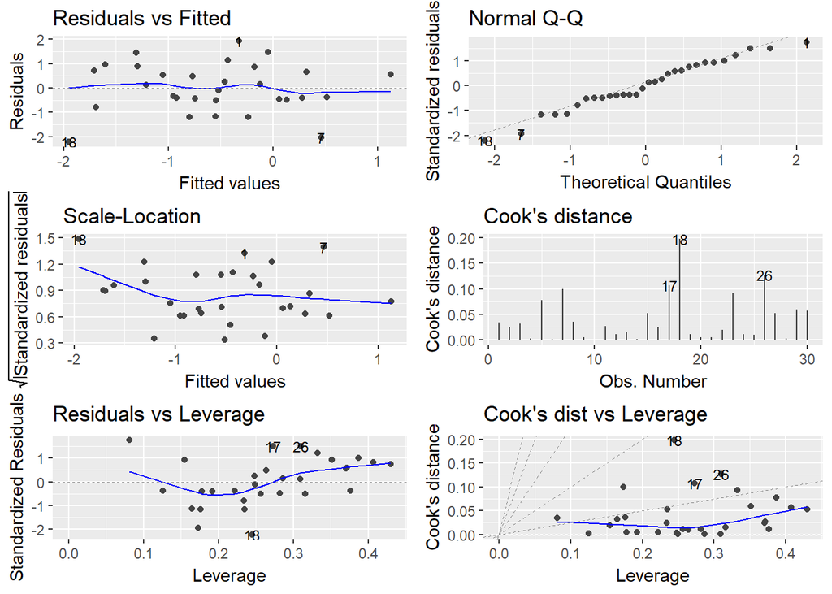

```r
#cheking the assumptions with a plot

autoplot(lm1, which = 1:6, label.size = 3)
```

Based on this plot I’d say that the residuals don’t differ from the normal distribution and the residuals are independent of the predictor levels.

The second model for hu_str2_diff_2nd

```r
# Model for hu_srt2_diff_2nd
lm2 <- lm( hu_str2_diff_2nd ~ Cs_avg+ avg_clustswitch + avg_groupsize + avg_groupnumb+ Pr+avg_sharpswitch+fluency, data = data)
summary(lm2)
```

```
FALSE
FALSE Call:
FALSE lm(formula = hu_str2_diff_2nd ~ Cs_avg + avg_clustswitch + avg_groupsize +
FALSE     avg_groupnumb + Pr + avg_sharpswitch + fluency, data = data)
FALSE
FALSE Residuals:
FALSE      Min       1Q   Median       3Q      Max
FALSE -1.45331 -0.61178  0.02989  0.43425  2.17671
FALSE
FALSE Coefficients:
FALSE                 Estimate Std. Error t value Pr(>|t|)
FALSE (Intercept)     -3.06357    1.85362  -1.653    0.113
FALSE Cs_avg          -0.24435    0.29963  -0.815    0.424
FALSE avg_clustswitch  0.37353    0.60236   0.620    0.542
FALSE avg_groupsize   -0.38003    0.81471  -0.466    0.645
FALSE avg_groupnumb    2.15732    1.45950   1.478    0.154
FALSE Pr               1.04509    0.91089   1.147    0.264
FALSE avg_sharpswitch  0.30036    0.19780   1.518    0.143
FALSE fluency         -0.02760    0.02952  -0.935    0.360
FALSE
FALSE Residual standard error: 0.9361 on 22 degrees of freedom
FALSE Multiple R-squared:  0.3967,  Adjusted R-squared:  0.2047
FALSE F-statistic: 2.066 on 7 and 22 DF,  p-value: 0.09149
```

```r
augment(lm2, data)
```

[output not shown]

[output cut: 38 more lines]

```
FALSE 16 -0.93738964 0.23414452 0.9292186 5.003366e-02 -1.14421478
FALSE 17  1.17192943 0.27308478 0.9100067 1.012429e-01  1.46831892
FALSE 18 -0.63807766 0.24457957 0.9446786 2.488980e-02 -0.78422375
FALSE 19  0.33148454 0.25642916 0.9544871 7.269104e-03  0.41064158
FALSE 20 -0.63883351 0.17757590 0.9457551 1.528268e-02 -0.75248975
FALSE 21  0.14509159 0.22168563 0.9574939 1.098863e-03  0.17568130
FALSE 22  0.37253193 0.15429073 0.9540799 4.270279e-03  0.43272678
FALSE 23  1.43129734 0.33262637 0.8785830 2.182277e-01  1.87157037
FALSE 24  0.01979705 0.28180936 0.9581527 3.054279e-05  0.02495408
FALSE 25  0.77171333 0.26379468 0.9378496 4.134393e-02  0.96076536
FALSE 26  0.03998351 0.30981079 0.9581087 1.483042e-04  0.05141118
FALSE 27  0.13265930 0.42984851 0.9573990 3.319265e-03  0.18767369
FALSE 28  0.42632618 0.12546758 0.9529879 4.253000e-03  0.48698419
FALSE 29  0.55565342 0.35167169 0.9462585 3.684572e-02  0.73716943
FALSE 30 -0.03372834 0.40719242 0.9581186 1.880156e-04 -0.04679495
```

```r
results2 <- stargazer(lm2,  title = "Results", align = TRUE, type = "text", out = ".txt")
```

```
FALSE
FALSE Results
FALSE ===============================================
FALSE                         Dependent variable:
FALSE                     ---------------------------
FALSE                          hu_str2_diff_2nd
FALSE -----------------------------------------------
FALSE Cs_avg                        -0.244
FALSE                               (0.300)
FALSE
FALSE avg_clustswitch                0.374
FALSE                               (0.602)
FALSE
FALSE avg_groupsize                 -0.380
FALSE                               (0.815)
FALSE
FALSE avg_groupnumb                  2.157
FALSE                               (1.460)
FALSE
FALSE Pr                             1.045
FALSE                               (0.911)
FALSE
FALSE avg_sharpswitch                0.300
FALSE                               (0.198)
FALSE
FALSE fluency                       -0.028
FALSE                               (0.030)
FALSE
FALSE Constant                      -3.064
FALSE                               (1.854)
FALSE
FALSE -----------------------------------------------
FALSE Observations                    30
FALSE R2                             0.397
FALSE Adjusted R2                    0.205
FALSE Residual Std. Error       0.936 (df = 22)
FALSE F Statistic             2.066* (df = 7; 22)
FALSE ===============================================
FALSE Note:               *p<0.1; **p<0.05; ***p<0.01
```

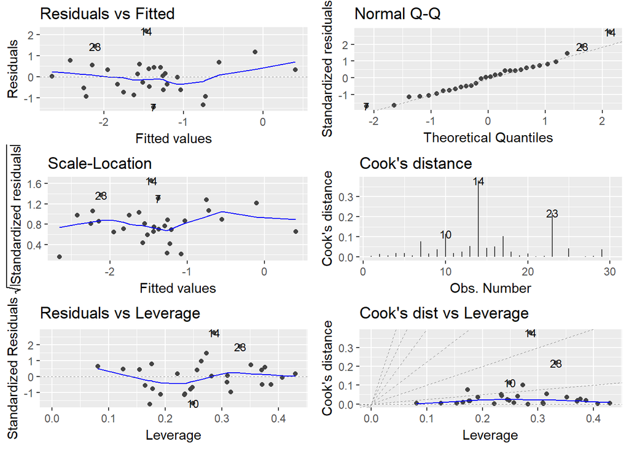

```r
autoplot(lm2, which = 1:6, label.size = 3)
```

This model didn’t occured in significant results.

In conclusion, the linear regression didn’t provided more information about the relationships, but we can see that using correction and the variability of assumptions could effect our result from what we publicate and the question is, which results could be called reliable?

### Permutation based statistic for correlation coefficients

After the linear regression analysis it is clear that there is some kind of relationship between the MMN effect of Hungarian S1 stimuli and the working memory capacity, that is why I was interested in other statistical tests which coul test the reliability of this relationship. That is why I conducted a permutation based analysis of the correlation coefficients. It controls the family-wise error rate by using the “max statistic” method for adjusting the p values in the case of multiple comparisons. I entered the seven EF variables into the analysis as one family, and the two MMN variables as a different family. This analysis is based on the assumption that if the data came from the same population of individuals, the values of the observations would be exchangeable.In this study, 10000 (p < .01) permutations were used (Groppe et al., 2011).

```r
for (i in 2:3) {
  x = data[,i]
  for (k in 1:7){
    y =  data[,k+3]
    perm.cor.test(x, y, nperm = 10000,"two.sided", progress = TRUE)
  }
}
# You have to use the print function to see the results, but because of the space I don't use it. I can' save the result just in pdf so i created two seperately datasets for the two MMN variables.
```

After running the permutation statistics I created two datasets from the results (because of some troubles with the function). The next two tables show the *p* values of the results of the 10000 permutation.

Permutation analysis results: hu_str1_diff_2nd.

| Cs_avg | Pr | fluency | avg_groupsize | avg_clusterswitch | avg_sharpswitch | avg_groupnumber |
| --- | --- | --- | --- | --- | --- | --- |
| 0.004 | 0.998 | 0.903 | 0.455 | 0.086 | 0.175 | 0.148 |

Permutation analysis results: hu_str2_diff_2nd.

| Cs_avg | Pr | fluency | avg_groupsize | avg_clusterswitch | avg_sharpswitch | avg_groupnumber |
| --- | --- | --- | --- | --- | --- | --- |
| 0.333 | 0.141 | 0.214 | 0.423 | 0.296 | 0.29 | 0.075 |

The permutation-based correlation analysis yielded a significant positive relation between the MMN effect for HU S1 stimuli and working memory capacity, *r* = .489, *p* = .004.